# PFG-bank: Data Driven Credit Card Design

## Setup

Please complete this Rmarkdown document by answering the questions in `pfg-bank.pdf` on Canvas (week10/). The code block below will load the historical data from exhibits 1 and 2. Please DO NOT change the code used to load the data. Create an HTML (Notebook) file with all your results and comments and push both the Rmarkdown and HTML file to GitLab when you are done. All analysis results MUST be reproducible (i.e., the TA and I must be able to recreate the HTML from the Rmarkdown file without changes or errors).

This is the final group assignment for MGTA 455 and you will be using git and GitLab. If two people edit the same file at the same time you could get what is called a “merge conflict”. git will not decide for you who’s change to accept so the team-lead will have to determine which edits to use. To avoid merge conflicts, always “pull” changes to the repo before you start working on any files. Then, when you are done, save and commit your changes, and then push them to GitLab. Make “pull first” a habit!

```r
exhibit1 <- readxl::read_excel("data/exhibits.xlsx", sheet = "exhibit1")
exhibit2 <- readxl::read_excel("data/exhibits.xlsx", sheet = "exhibit2")
part_factorial_1234 <- readr::read_csv("part_factorial_1234.csv")
part_factorial_19 <- readr::read_csv("part_factorial_19.csv")
part_factorial_172110 <- readr::read_csv("part_factorial_172110.csv")
```

## Preparation questions:

### 1. Why does Customer Lifetime Value vary with BK score? Why does Customer Lifetime Value vary with product? (See Exhibit 2 to help answer these questions) (3 points)

An individual’s BK score was a measure of risk — the higher the score, the more likely that person was to default on a financial obligation. When a person default on a financial obligation, he or she either does not pay for the interest or does not pay back the principal and pay for the interests altogether, which both hurt profit. Thus the higer the BK score, the lower the CLV as the risk that an individual.

Becasue different products create varing amount of profits. A card with higher annual fee and APR will create higher profit by charging more. A variable card will be more profitable than a fixed card because its margin is protected.

### 2. Are predictive models estimated on historical data useful in this case? If so, why? If not, why not? (4 points)

No. Becasue as the case said, even though the names being mailed to in Solicitation 92-1 were similar to those used in the previous mailings, many factors beyond PFG’s control had changed and could affect customers’ responses. Several of PFG’s competitors had launched major marketing campaigns during the holiday season. One competitor was aggressively marketing no-fee cards and a second was offering a substantial rebate program. In addition, interest rates had dropped: in the past six months, PFG’s cost of borrowing had fallen almost a full percentage point.

Therefore, what triggered the most response in the past may not carry into the present. We need to be careful when using historical data. Despite that attitudes can shift with time, historical data do have the ability to manifest past customer’s preference that can provide insights to us. We want to use the historical data to find the best historical offering based onlimited historical offerings for each BK score group.

### 3. Is there a “best product” that will likely be preferred by all customers? (3 points)

Yes. A fixed card with lowest APR, zero annual fee is likely to be preferred by all customers as it is at the lowest cost. However, this card may not valuable to the bank as it also has the lowest CLV which may not maximize bank’s profit.

### 3.5. The interlude (note on our situation, refer more to piazza’s private posts)

One of our teammate thought the test is unlimited and without telling and getting consent from all other team members, logged in and did round 1 on his own just trying out. We felt extremely unfair that the test was run without our approval, and we need to bear the consequences that we have wasted our only testing chance and the destiny to fail in the case.

In his own words: " I did not read the case carefully, and ran the round 1 without telling other group members. So actually this is all my own fault. My teammates think this is unfair to them, so do I. Now we cannot step further. If possible, could you let our group run round 1 again? Thank you on my behalf. If no, can you at least let us give you our correct round 1 data and get the result? Or, if this is still no good, I plead that you reset round 1 for our team and give me zero point. At least the penalty should only be on me."

We reached out to ask for another testing chance and were rejected in consideration of fairness to others. We were then encouraged to try our best despite the mishap and the missing data it results. So here we are, decide to give our best shot given the situation.

### 4. Describe and justify your testing strategy (10 points)

We thought of two kinds of testing strategy.

First: historical data is somewhat reliable. We assume that there will be no preference difference across time. Among the 36 full factorial design, 14 have been tested in the historical data and 22 untested. Within the historical data, we will find out the best product for each BK score group among the 14 products and we will add this three test condition to round 1. We will then have 25 tests in round 1 that complete a full factorial design with historical data. We will select the best product for each segment based on response rate.

Second: historical data is completely not reliable. We will not use the historical data at all and will fully rely on testing in round 1. Because adding interactions are expensive, we will perform the 18 necessary tests in round 1 and build a logistic model with data that comes out of round 1 to explain the interaction effects. We will then use the model to predict for all 36 cases and pick the three products for each segment based on probability.

Final Approach: Unfortunately, we messed up with round 1 testing and had to redesign the best actionable strategy using the imperfect resources in hand. We started by comparing the pros and cons of the two datasets. Historical data has two evident downsides: first, the fixed_var variable is imbalanced as most of the products are fixed-rate; second, the economic environment and customer preference may change as time goes by, which means certain products might be not as attractive to the customer as before. Compared to the historical data, the disadvantages of round 1 testing data are more evident since it did not test any products with 19.8% APR and products with 16.8% APR at a variable rate (see Exhibit 1). Considering the data integrity, we then decided to run a logistic regression model on the historical dataset and adjust the prediction based on the response rate gained from the testing result.

After building the logistic model using “apr”, “fixed_var”, “annual_fee”, “bk_score” from historical dataset(see Exhibit 2), we generated a list of predicted response rate for each 36 products. To make up the defect of this prediction caused by the imbalance between fixed- and variable-rates, we came up with an approach to adjust the prediction by utilizing “multiplier”. We accordingly appended the 18 available response rate from the testing results and calculated a ratio by dividing the testing response rate by the predicted response rate. We selected the product with APR 14.9% and calculated the mean value of the fixed and variable groups. The multiplier of variable/fixed is 1.117 (see Exhibit 3). We weighted the prediction of the variable product using this multiplier, resulting in our final prediction. After multiplying the CLV of each group and returning the anticipated profit, we sorted the data frame descendingly by the value of profit. For each BK score group, we chose 2 highest unit profit solicitations and decided to assign the remaining mailing by 4:1 for the highest and second-highest solicitation. We believe that splitting the remaining mailing will substantially offset the bias caused by systematic errors.

### Exhibit

#### Exhibit 1

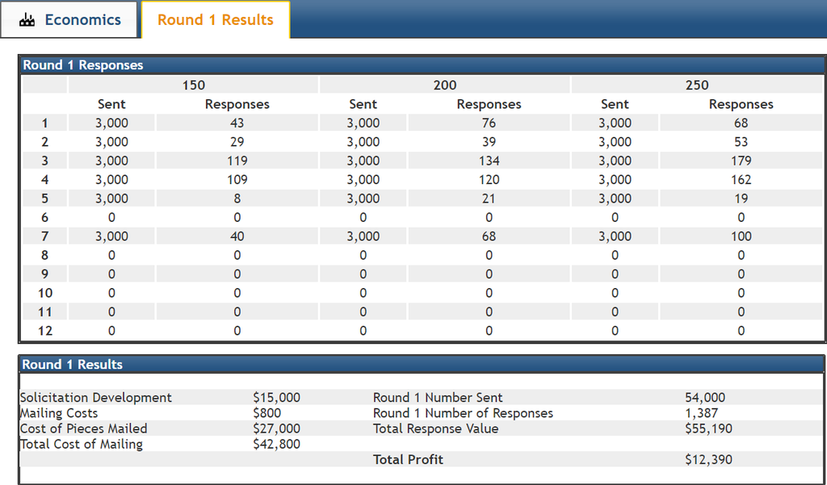

#### Exhibit 2

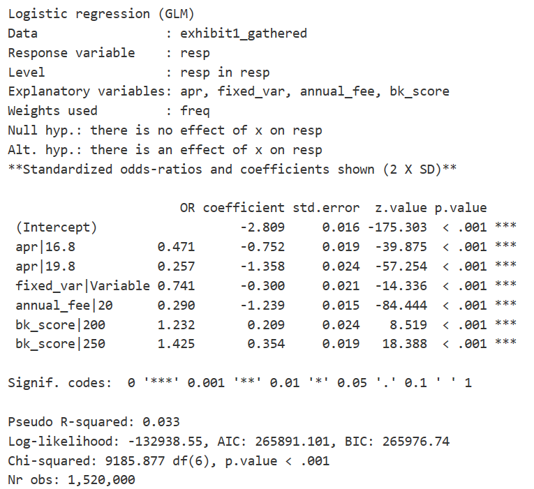

#### Exhibit 3

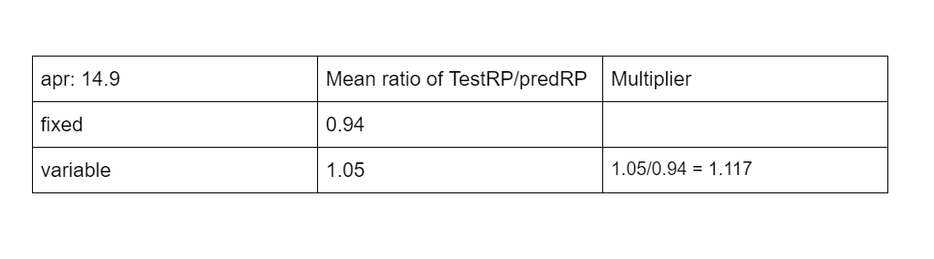